# Q & K Box 13.8

Ryeland et al (2017) studied the roosting behaviour of several species of shorebirds. They recorded the proportion of time (number of minutes as a proportion of total minutes in a video bout) individuals of various species spent in the backrest position while roosting. They used a binomial model with a logit link for proportions with four fixed predictors recorded for each video bout: ambient temperature, wind speed, size of group focal bird was in, and distance focal bird was from the observer. We will analyze the data for a single species, the sharp-tailed sandpiper (*Calidris acuminata*). This would be a standard binomial GLM except that more than one bird was sometimes recorded in each bout so bout was included as a random effect since birds closer together may be correlated in their behaviour. The resulting model is a binomial GLMM.

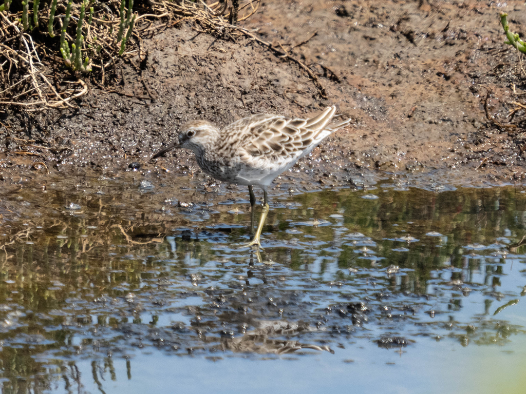

Sharp-tailed sandpiper. Mick Keough, , via Wikimedia Commons

The paper is [here](https://doi.org/10.1111/1365-2435.12814)

Ryeland, J., Weston, M. A., Symonds, M. R. E. & Overgaard, J. (2017). Bill size mediates behavioural thermoregulation in birds. *Functional Ecology*, 31, 885-93.

### Preliminaries

First, load the required packages (car, performance, MuMIn, lme4, glmmTMB, lmtest, ggplot2)

Import ryeland data file (ryeland.csv)

```r
ryeland <- read.csv("../data/ryeland.csv")
head(ryeland)
```

|  | dist | groupsize | temp | wind | filmp | timehb | vbout | olre |
| --- | --- | --- | --- | --- | --- | --- | --- | --- |
| 1 | 30 | 40 | 15.375 | 2.075 | 9.492067 | 0.000000 | s1 | 1 |
| 2 | 30 | 40 | 15.375 | 2.075 | 13.090400 | 11.424667 | s1 | 2 |
| 3 | 50 | 20 | 15.560 | 3.220 | 22.553333 | 18.456400 | s6 | 3 |
| 4 | 50 | 20 | 15.560 | 3.220 | 22.553333 | 15.066133 | s6 | 4 |
| 5 | 50 | 30 | 15.300 | 2.900 | 5.025000 | 1.217117 | s7 | 5 |
| 6 | 50 | 30 | 15.300 | 2.900 | 5.025000 | 1.217333 | s7 | 6 |

Create proportion of time facing back

```r
ryeland$prophb<-ryeland$timehb/ryeland$filmp
```

Create success and fail columns

```r
ryeland$success<-as.integer(ryeland$timehb)
ryeland$fail<-as.integer(ryeland$filmp-ryeland$timehb)
```

Create response variable

```r
ryeland.prop<-cbind(ryeland$success,ryeland$fail)
```

### Preliminary checks

Scatterplots

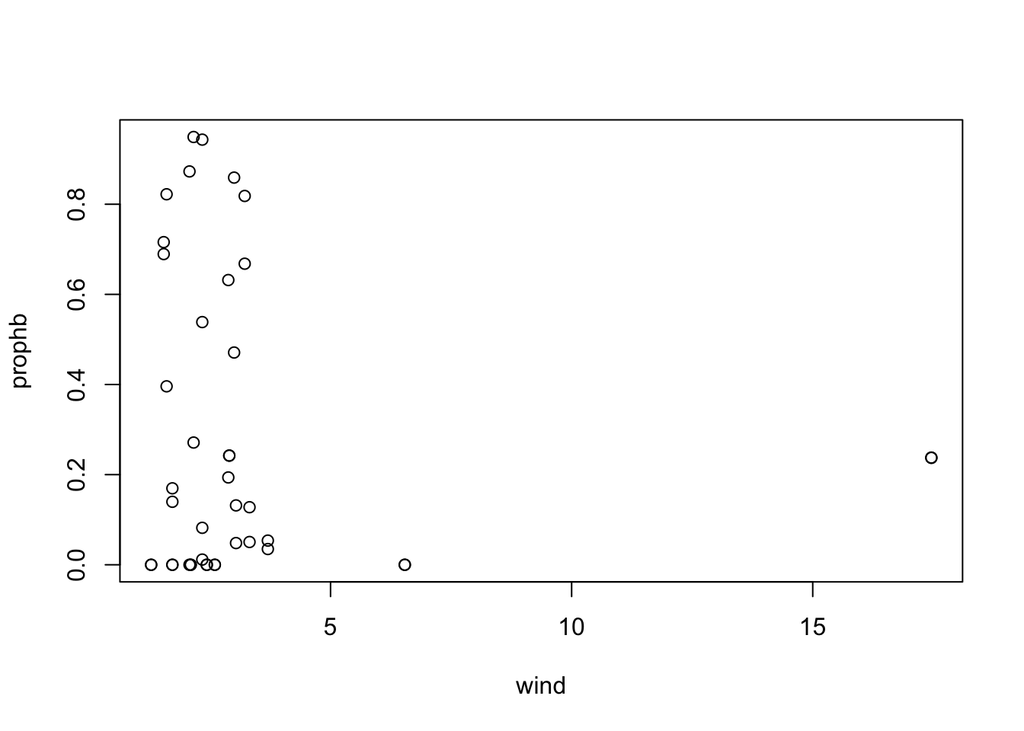

```r
plot(prophb~wind, data=ryeland)
```

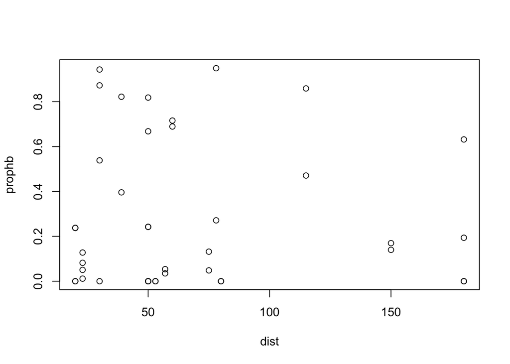

```r
plot(prophb~dist, data=ryeland)
```

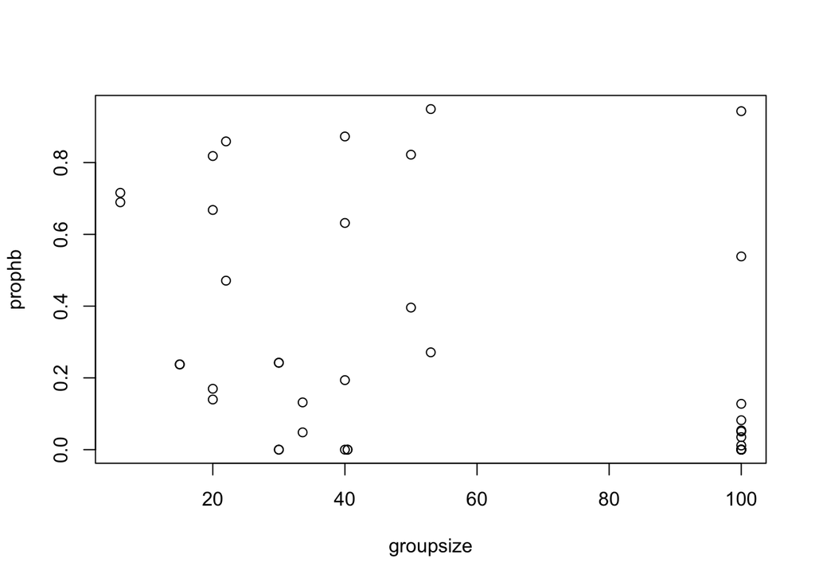

```r
plot(prophb~groupsize, data=ryeland)
```

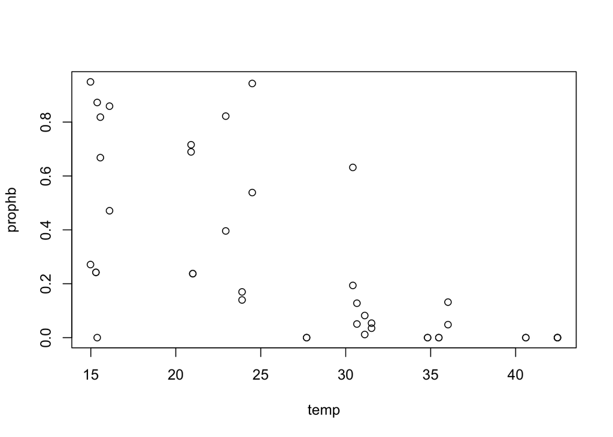

```r
plot(prophb~temp, data=ryeland)
```

Boxplots

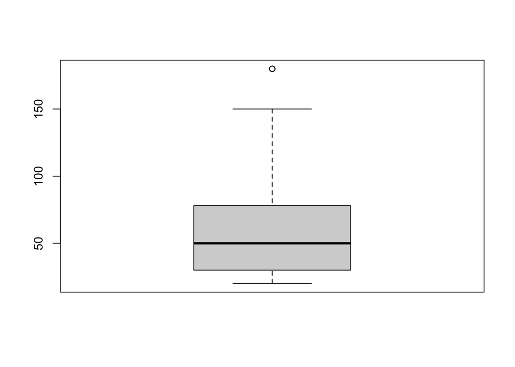

```r
boxplot(ryeland$dist)
```

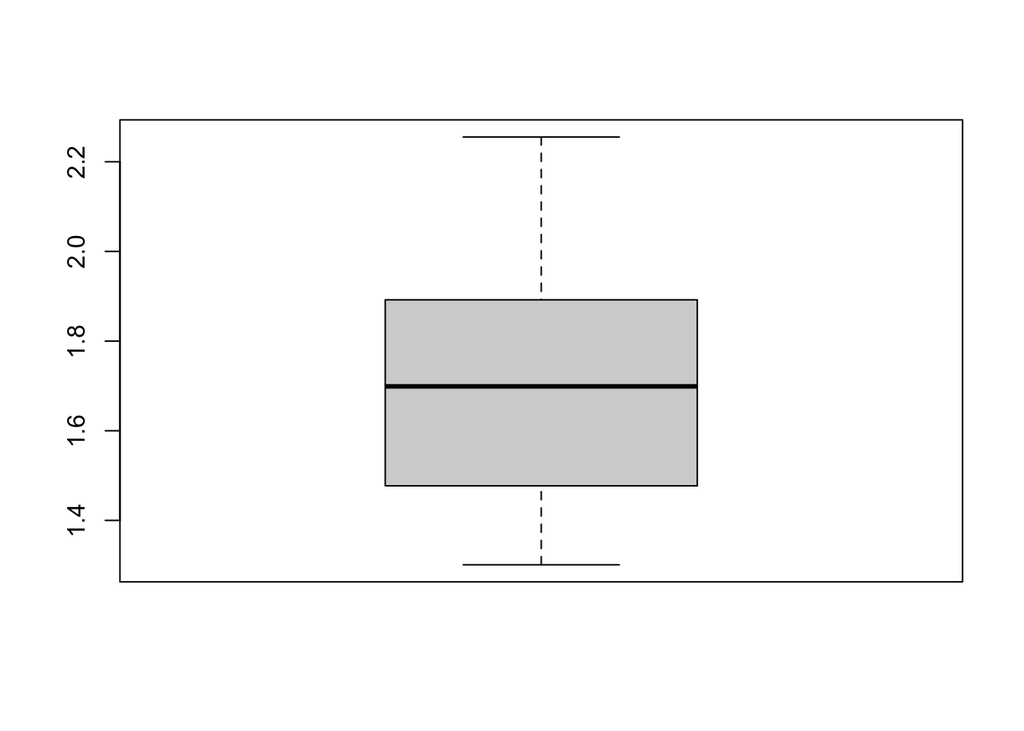

```r
boxplot(log10(ryeland$dist))
```

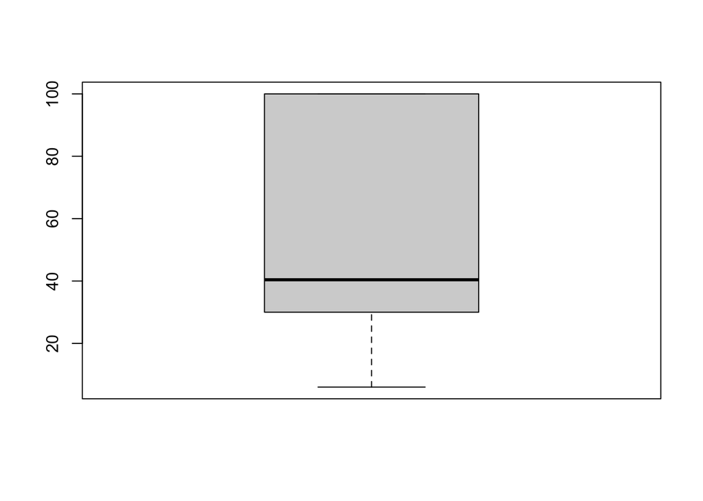

```r
boxplot(ryeland$groupsize)
```

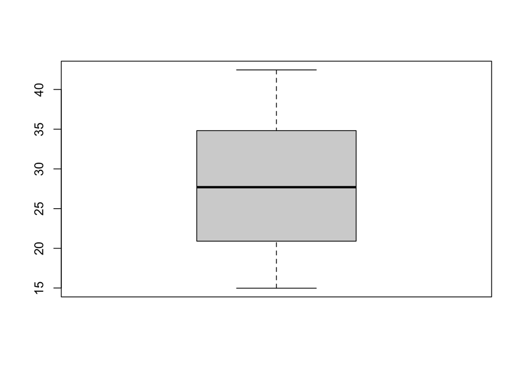

```r
boxplot(ryeland$temp)
```

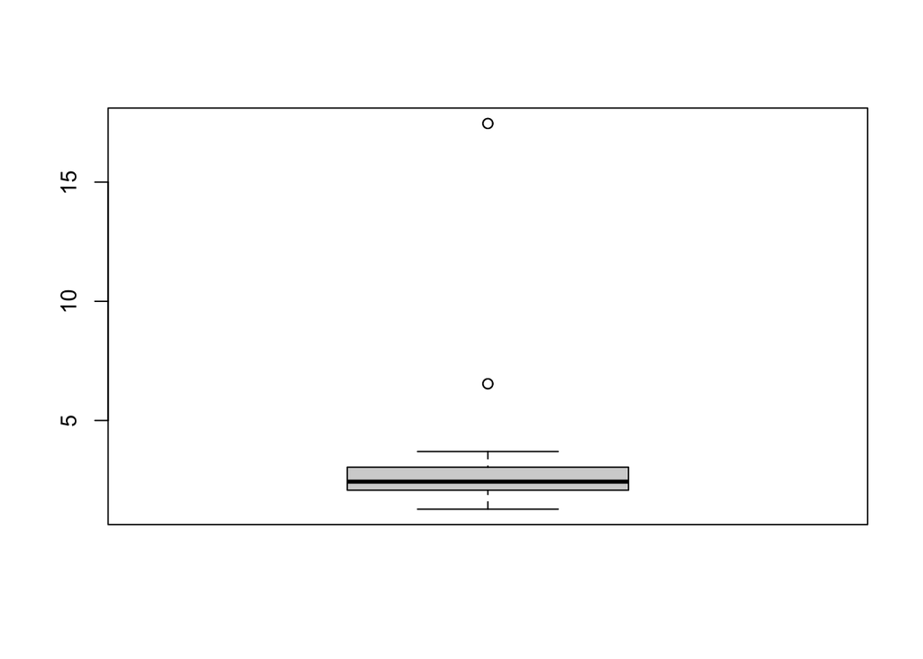

```r
boxplot(ryeland$wind)
```

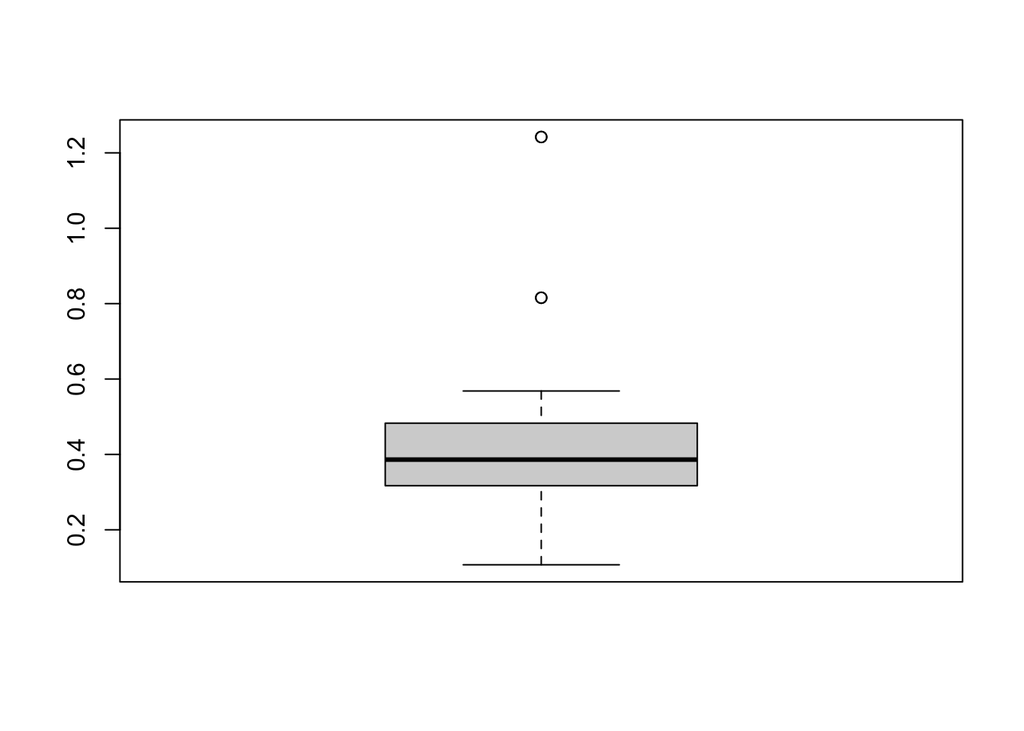

```r
boxplot(log10(ryeland$wind))
```

Check collinearity

```r
vif(lm(ryeland$prophb ~ dist+groupsize+temp+wind,data=ryeland))
```

```
##      dist groupsize      temp      wind
##  1.227653  2.034472  1.854943  1.164948
```

```r
cor(ryeland[,c('dist','groupsize','temp','wind')])
```

```
##                  dist  groupsize        temp        wind
## dist       1.00000000 -0.2030191  0.01623776 -0.27381162
## groupsize -0.20301907  1.0000000  0.65247217 -0.15742617
## temp       0.01623776  0.6524722  1.00000000 -0.04701293
## wind      -0.27381162 -0.1574262 -0.04701293  1.00000000
```

### Fit GLMM with binomial distribution and test predictor effects

```r
ryeland1.glmer<-glmer(ryeland.prop~dist+groupsize+temp+wind+(1|vbout),data=ryeland,family=binomial)
summary(ryeland1.glmer)
```

```
## Generalized linear mixed model fit by maximum likelihood (Laplace
##   Approximation) [glmerMod]
##  Family: binomial  ( logit )
## Formula: ryeland.prop ~ dist + groupsize + temp + wind + (1 | vbout)
##    Data: ryeland
##
##      AIC      BIC   logLik deviance df.resid
##    224.0    234.4   -106.0    212.0       36
##
## Scaled residuals:
##     Min      1Q  Median      3Q     Max
## -3.5293 -0.6966 -0.2213  0.4084  3.3384
##
## Random effects:
##  Groups Name        Variance Std.Dev.
##  vbout  (Intercept) 1.428    1.195
## Number of obs: 42, groups:  vbout, 21
##
## Fixed effects:
##              Estimate Std. Error z value Pr(>|z|)
## (Intercept)  4.467829   1.231907   3.627 0.000287 ***
## dist         0.003639   0.007703   0.472 0.636655
## groupsize    0.003162   0.013106   0.241 0.809377
## temp        -0.249287   0.055305  -4.507 6.56e-06 ***
## wind        -0.031059   0.093908  -0.331 0.740840
## ---
## Signif. codes:  0 '***' 0.001 '**' 0.01 '*' 0.05 '.' 0.1 ' ' 1
##
## Correlation of Fixed Effects:
##           (Intr) dist   gropsz temp
## dist      -0.375
## groupsize -0.155  0.453
## temp      -0.551 -0.362 -0.597
## wind      -0.395  0.387  0.345 -0.200
```

```r
AIC(ryeland1.glmer)
```

```
## [1] 224.0019
```

```r
AICc(ryeland1.glmer)
```

```
## [1] 226.4019
```

```r
anova(ryeland1.glmer, type="lrtest")
```

|  | npar | Sum Sq | Mean Sq | F value |
| --- | --- | --- | --- | --- |
| dist | 1 | 0.08309428 | 0.08309428 | 0.08309428 |
| groupsize | 1 | 8.33113715 | 8.33113715 | 8.33113715 |
| temp | 1 | 21.99708206 | 21.99708206 | 21.99708206 |
| wind | 1 | 0.10942768 | 0.10942768 | 0.10942768 |

Test wind

```r
ryeland2.glmer<-glmer(ryeland.prop~dist+groupsize+temp+(1|vbout),data=ryeland,family=binomial)
lrtest(ryeland1.glmer, ryeland2.glmer)
```

|  | #Df | LogLik | Df | Chisq | Pr(>Chisq) |
| --- | --- | --- | --- | --- | --- |
| 1 | 6 | -106.001 | NA | NA | NA |
| 2 | 5 | -106.055 | -1 | 0.1080783 | 0.7423426 |

Test temp

```r
ryeland3.glmer<-glmer(ryeland.prop~dist+groupsize+wind+(1|vbout),data=ryeland,family=binomial)
lrtest(ryeland1.glmer, ryeland3.glmer)
```

|  | #Df | LogLik | Df | Chisq | Pr(>Chisq) |
| --- | --- | --- | --- | --- | --- |
| 1 | 6 | -106.0010 | NA | NA | NA |
| 2 | 5 | -114.7155 | -1 | 17.42908 | 2.982277e-05 |

Test groupsize

```r
ryeland4.glmer<-glmer(ryeland.prop~dist+temp+wind+(1|vbout),data=ryeland,family=binomial)
lrtest(ryeland1.glmer, ryeland4.glmer)
```

|  | #Df | LogLik | Df | Chisq | Pr(>Chisq) |
| --- | --- | --- | --- | --- | --- |
| 1 | 6 | -106.001 | NA | NA | NA |
| 2 | 5 | -106.030 | -1 | 0.05807958 | 0.8095574 |

Test dist

```r
ryeland5.glmer<-glmer(ryeland.prop~groupsize+wind+temp+wind+(1|vbout),data=ryeland,family=binomial)
lrtest(ryeland1.glmer, ryeland5.glmer)
```

|  | #Df | LogLik | Df | Chisq | Pr(>Chisq) |
| --- | --- | --- | --- | --- | --- |
| 1 | 6 | -106.0010 | NA | NA | NA |
| 2 | 5 | -106.1113 | -1 | 0.2206255 | 0.6385637 |

Check residuals

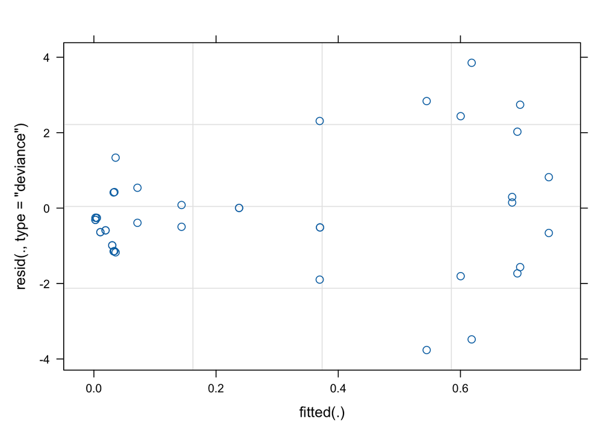

```r
plot(ryeland1.glmer, resid(., type = "deviance") ~ fitted(.))
```

```r
residuals(ryeland1.glmer, type="deviance")
```

```
##            1            2            3            4            5            6
## -3.763382397  2.838021514  0.820443739 -0.659751777 -0.512406414 -0.512406414
##            7            8            9           10           11           12
##  3.853484748 -3.481058752 -1.730565806  2.026342723  2.741521942 -1.564149761
##           13           14           15           16           17           18
##  0.295075364  0.148573175 -0.987378774 -0.987378774  0.082333978 -0.495520488
##           19           20           21           22           23           24
##  0.414659592 -1.146389940  2.310400451 -1.896027347 -0.589653923 -0.589653923
##           25           26           27           28           29           30
## -1.172944131  1.338110379  0.004295672  0.004295672 -0.259838637 -0.259838637
##           31           32           33           34           35           36
## -0.312696722 -0.312696722 -0.256375362 -0.256375362 -1.804327926  2.437750572
##           37           38           39           40           41           42
## -0.390142369  0.539597491  0.425766437 -1.139834682 -0.637195407 -0.637195407
```

### Check overdispersion

(code from Zuur et al 2013)

```r
presid1 <- resid(ryeland1.glmer, type="pearson")
ssize1 <- nrow(ryeland)
params1 <- length(fixef(ryeland1.glmer)+1)
disp1 <- sum(presid1^2)/(ssize1-params1)
disp1
```

```
## [1] 2.233862
```

### Add Observation Level Random Effect into model and retest the predictors

```r
ryeland6.glmer<-glmer(ryeland.prop~dist+groupsize+temp+wind+(1|vbout)+(1|olre),data=ryeland,family=binomial)
summary(ryeland6.glmer)
```

```
## Generalized linear mixed model fit by maximum likelihood (Laplace
##   Approximation) [glmerMod]
##  Family: binomial  ( logit )
## Formula: ryeland.prop ~ dist + groupsize + temp + wind + (1 | vbout) +
##     (1 | olre)
##    Data: ryeland
##
##      AIC      BIC   logLik deviance df.resid
##    176.0    188.1    -81.0    162.0       35
##
## Scaled residuals:
##     Min      1Q  Median      3Q     Max
## -1.1295 -0.3654 -0.1098  0.1465  0.8065
##
## Random effects:
##  Groups Name        Variance Std.Dev.
##  olre   (Intercept) 2.2818   1.5106
##  vbout  (Intercept) 0.6525   0.8078
## Number of obs: 42, groups:  olre, 42; vbout, 21
##
## Fixed effects:
##              Estimate Std. Error z value Pr(>|z|)
## (Intercept)  5.035378   1.391444   3.619 0.000296 ***
## dist         0.004883   0.008585   0.569 0.569523
## groupsize    0.006642   0.014688   0.452 0.651091
## temp        -0.289309   0.063606  -4.548  5.4e-06 ***
## wind        -0.021925   0.104823  -0.209 0.834321
## ---
## Signif. codes:  0 '***' 0.001 '**' 0.01 '*' 0.05 '.' 0.1 ' ' 1
##
## Correlation of Fixed Effects:
##           (Intr) dist   gropsz temp
## dist      -0.355
## groupsize -0.125  0.448
## temp      -0.567 -0.368 -0.607
## wind      -0.387  0.391  0.344 -0.203
## optimizer (Nelder_Mead) convergence code: 0 (OK)
## Model failed to converge with max|grad| = 0.00479299 (tol = 0.002, component 1)
```

```r
AIC(ryeland6.glmer)
```

```
## [1] 175.9722
```

```r
AICc(ryeland6.glmer)
```

```
## [1] 179.2663
```

Test wind

```r
ryeland7.glmer<-glmer(ryeland.prop~dist+groupsize+temp+(1|vbout)+(1|olre),data=ryeland,family=binomial)
lrtest(ryeland6.glmer, ryeland7.glmer)
```

|  | #Df | LogLik | Df | Chisq | Pr(>Chisq) |
| --- | --- | --- | --- | --- | --- |
| 1 | 7 | -80.98611 | NA | NA | NA |
| 2 | 6 | -81.00796 | -1 | 0.04368475 | 0.8344412 |

Test temp

```r
ryeland8.glmer<-glmer(ryeland.prop~dist+groupsize+wind+(1|vbout)+(1|olre),data=ryeland,family=binomial)
lrtest(ryeland6.glmer, ryeland8.glmer)
```

|  | #Df | LogLik | Df | Chisq | Pr(>Chisq) |
| --- | --- | --- | --- | --- | --- |
| 1 | 7 | -80.98611 | NA | NA | NA |
| 2 | 6 | -90.08498 | -1 | 18.19772 | 1.991168e-05 |

Test groupsize

```r
ryeland9.glmer<-glmer(ryeland.prop~dist+temp+wind+(1|vbout)+(1|olre),data=ryeland,family=binomial)
lrtest(ryeland6.glmer, ryeland9.glmer)
```

|  | #Df | LogLik | Df | Chisq | Pr(>Chisq) |
| --- | --- | --- | --- | --- | --- |
| 1 | 7 | -80.98611 | NA | NA | NA |
| 2 | 6 | -81.08791 | -1 | 0.203586 | 0.6518418 |

Test dist

```r
ryeland10.glmer<-glmer(ryeland.prop~groupsize+wind+temp+wind+(1|vbout)+(1|olre),data=ryeland,family=binomial)
lrtest(ryeland6.glmer, ryeland10.glmer)
```

|  | #Df | LogLik | Df | Chisq | Pr(>Chisq) |
| --- | --- | --- | --- | --- | --- |
| 1 | 7 | -80.98611 | NA | NA | NA |
| 2 | 6 | -81.14590 | -1 | 0.3195652 | 0.5718691 |

Check residuals

```r
residuals(ryeland6.glmer, type="deviance")
```

```
##             1             2             3             4             5
## -1.5447395250  0.5172864056  0.1196810203 -0.0322630604 -0.4684873115
##             6             7             8             9            10
## -0.4684873115  0.5325649521 -0.4136943237 -0.2520815525  0.4244747147
##            11            12            13            14            15
##  0.8886066062  0.0991229301  0.2056759672  0.1944258321 -0.8634133275
##            16            17            18            19            20
## -0.8634133275 -0.0923987236 -0.2057548325  0.1292967041 -0.8108564846
##            21            22            23            24            25
##  0.4656016351  0.0813928692 -0.5191604731 -0.5191604731 -0.5562204040
##            26            27            28            29            30
##  0.6709928891  0.0083211848  0.0083211848 -0.1931770732 -0.1931770732
##            31            32            33            34            35
## -0.2297641770 -0.2297641770 -0.1805826167 -0.1805826167  0.0216933895
##            36            37            38            39            40
##  0.5010090500  0.0009363983  0.2191309741  0.1477818160 -0.7981929022
##            41            42
## -0.5028424989 -0.5028424989
```

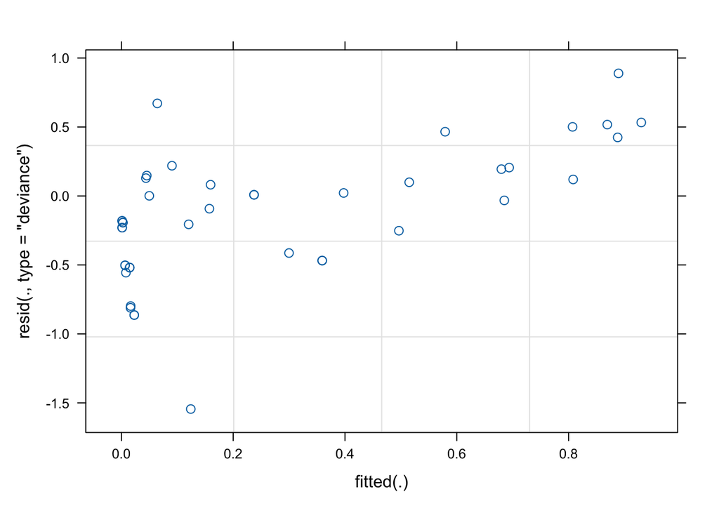

```r
plot(ryeland6.glmer, resid(., type = "deviance") ~ fitted(.))
```

### Fit model with only temp to match paper

```r
ryeland11.glmer<-glmer(ryeland.prop~temp+(1|vbout)+(1|olre),data=ryeland,family=binomial)
summary(ryeland11.glmer)
```

```
## Generalized linear mixed model fit by maximum likelihood (Laplace
##   Approximation) [glmerMod]
##  Family: binomial  ( logit )
## Formula: ryeland.prop ~ temp + (1 | vbout) + (1 | olre)
##    Data: ryeland
##
##      AIC      BIC   logLik deviance df.resid
##    170.6    177.5    -81.3    162.6       38
##
## Scaled residuals:
##     Min      1Q  Median      3Q     Max
## -1.1282 -0.3502 -0.1082  0.1626  0.8116
##
## Random effects:
##  Groups Name        Variance Std.Dev.
##  olre   (Intercept) 2.2639   1.505
##  vbout  (Intercept) 0.7815   0.884
## Number of obs: 42, groups:  olre, 42; vbout, 21
##
## Fixed effects:
##             Estimate Std. Error z value Pr(>|z|)
## (Intercept)  5.13800    1.26250   4.070 4.71e-05 ***
## temp        -0.27009    0.05083  -5.313 1.08e-07 ***
## ---
## Signif. codes:  0 '***' 0.001 '**' 0.01 '*' 0.05 '.' 0.1 ' ' 1
##
## Correlation of Fixed Effects:
##      (Intr)
## temp -0.953
```

```r
AIC(ryeland11.glmer)
```

```
## [1] 170.5968
```

```r
AICc(ryeland11.glmer)
```

```
## [1] 171.6779
```

Plot temp to match paper **Need to add fit logistic curve?**

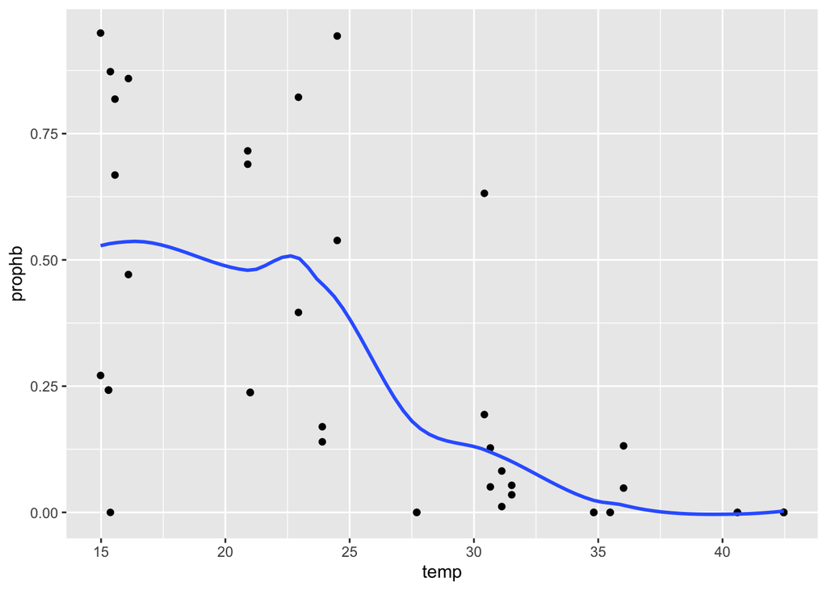

```r
ggplot(ryeland, aes(temp, prophb)) + geom_point() +
  geom_smooth(method = "loess", span = 0.5, se = FALSE)
```

```r
ryeland.glmmb <- glmmTMB(ryeland.prop~groupsize+wind+temp+wind+(1|vbout), family=binomial, data=ryeland)
summary(ryeland.glmmb)
```

```
##  Family: binomial  ( logit )
## Formula:          ryeland.prop ~ groupsize + wind + temp + wind + (1 | vbout)
## Data: ryeland
##
##      AIC      BIC   logLik deviance df.resid
##    222.2    230.9   -106.1    212.2       37
##
## Random effects:
##
## Conditional model:
##  Groups Name        Variance Std.Dev.
##  vbout  (Intercept) 1.452    1.205
## Number of obs: 42, groups:  vbout, 21
##
## Conditional model:
##             Estimate Std. Error z value Pr(>|z|)
## (Intercept)  4.69865    1.14625   4.099 4.15e-05 ***
## groupsize    0.00034    0.01174   0.029    0.977
## wind        -0.04793    0.08722  -0.550    0.583
## temp        -0.24056    0.05164  -4.658 3.19e-06 ***
## ---
## Signif. codes:  0 '***' 0.001 '**' 0.01 '*' 0.05 '.' 0.1 ' ' 1
```

### Now fit betabinomial to compare to OLRE

```r
ryeland.glmmbb <- glmmTMB(ryeland.prop~dist+groupsize+temp+wind+(1|vbout),data=ryeland,family=betabinomial(link="logit"))
summary(ryeland.glmmbb)
```

```
##  Family: betabinomial  ( logit )
## Formula:          ryeland.prop ~ dist + groupsize + temp + wind + (1 | vbout)
## Data: ryeland
##
##      AIC      BIC   logLik deviance df.resid
##    178.7    190.8    -82.3    164.7       35
##
## Random effects:
##
## Conditional model:
##  Groups Name        Variance Std.Dev.
##  vbout  (Intercept) 0.1244   0.3528
## Number of obs: 42, groups:  vbout, 21
##
## Dispersion parameter for betabinomial family ():  2.6
##
## Conditional model:
##              Estimate Std. Error z value Pr(>|z|)
## (Intercept)  3.397445   1.027823   3.305 0.000948 ***
## dist         0.002152   0.006015   0.358 0.720449
## groupsize    0.006846   0.009837   0.696 0.486472
## temp        -0.193107   0.048463  -3.985 6.76e-05 ***
## wind        -0.016325   0.066960  -0.244 0.807385
## ---
## Signif. codes:  0 '***' 0.001 '**' 0.01 '*' 0.05 '.' 0.1 ' ' 1
```

```r
AICc(ryeland.glmmbb)
```

```
## [1] 181.9456
```

Test temperature

```r
ryeland1.glmmbb <- glmmTMB(ryeland.prop~dist+groupsize+wind+(1|vbout),data=ryeland,family=betabinomial(link="logit"))
lrtest(ryeland.glmmbb, ryeland1.glmmbb)
```

|  | #Df | LogLik | Df | Chisq | Pr(>Chisq) |
| --- | --- | --- | --- | --- | --- |
| 1 | 7 | -82.32575 | NA | NA | NA |
| 2 | 6 | -91.87232 | -1 | 19.09315 | 1.244906e-05 |